# homework1

# Exercise 4

1. What is the default geom associated with `stat_summary()`? How could you rewrite the previous plot to use that geom function instead of the stat function?

   Answer:

   ```
   ## No summary function supplied, defaulting to `mean_se()
   ```

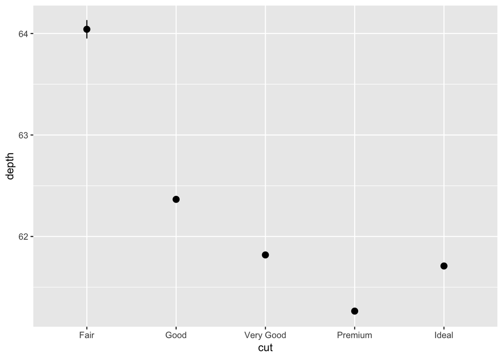

   ```r
   ggplot(data = diamonds) +
     geom_pointrange(mapping = aes(x = cut, y = depth), stat = "summary")
   ```

   The default geom for stat_summary is `geom_pointrange()`.
2. What does `geom_col()` do? How is it different to `geom_bar()`?

   Answer:

   Use `geom_col()` when you want the heights of the bars to represent values in the data. And `geom_bar` uses `stat_count` by default and counts the number of cases at each x position. `geom_col' uses`stat_identity` and leaves the data as is.
3. What variables does `stat_smooth()` compute? What parameters control its behaviour?

   Answer:

   Computed variables:
   - y: predicetd value
   - ymin: lower pointwise confidence interval around the mean
   - ymax: upper pointwise confidence interval around the mean
   - se: standard error

   `method` can control its behavior, for example, different methods including lm, glm, gam, loess.

# Exercise 5

1. What is the problem with this plot? How could you improve it?

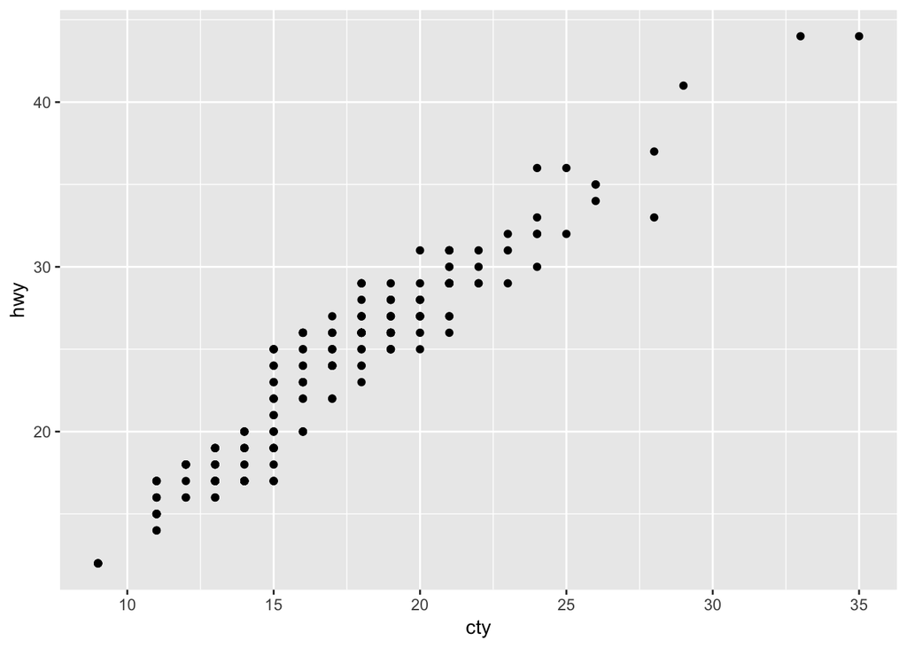

   ```r
   ggplot(data = mpg, mapping = aes(x = cty, y = hwy)) +
     geom_point()
   ```

   Overplotting. For each `cty` and `hwy` there could be multiple values. I will use `jitter` position adjustment.

   Answer:

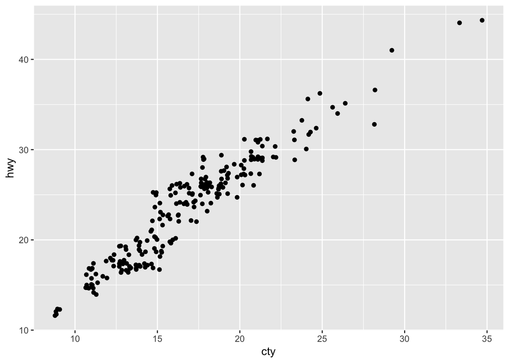

   ```r
   ggplot(data = mpg, mapping = aes(x = cty, y = hwy)) +
     geom_point(position = "jitter")
   ```

2. What parameters to `geom_jitter()` control the amount of jittering?

   Answer:

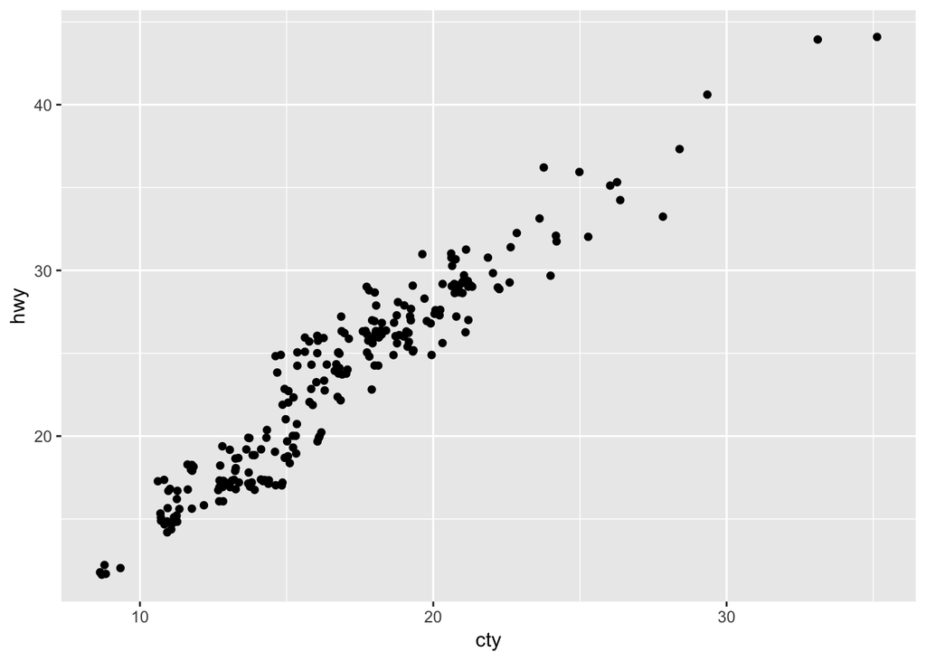

   ```r
   ggplot(data = mpg, mapping = aes(x = cty, y = hwy)) +
    geom_point(position = position_jitter(width = 0.4))
   ```

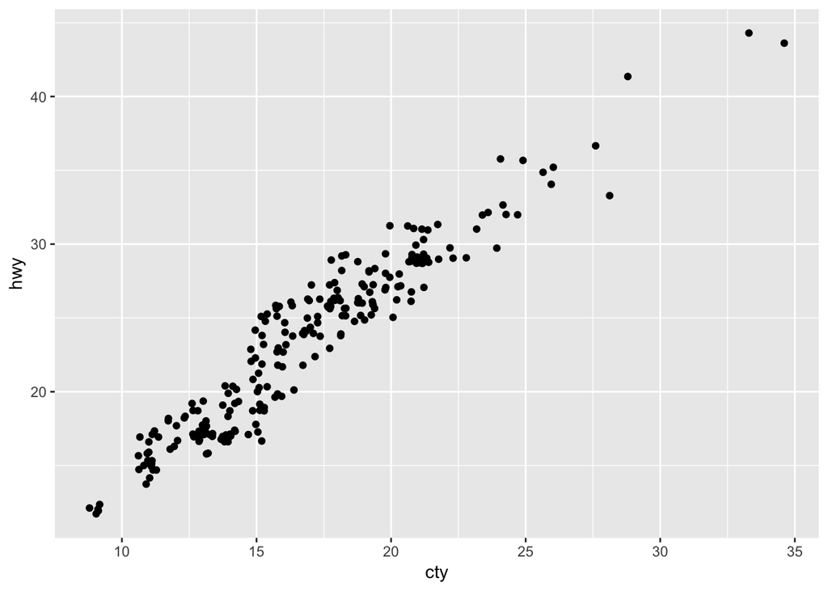

   ```r
   ggplot(data = mpg, mapping = aes(x = cty, y = hwy)) +
    geom_point(position = position_jitter(height = 0.4))
   ```

   Answer:

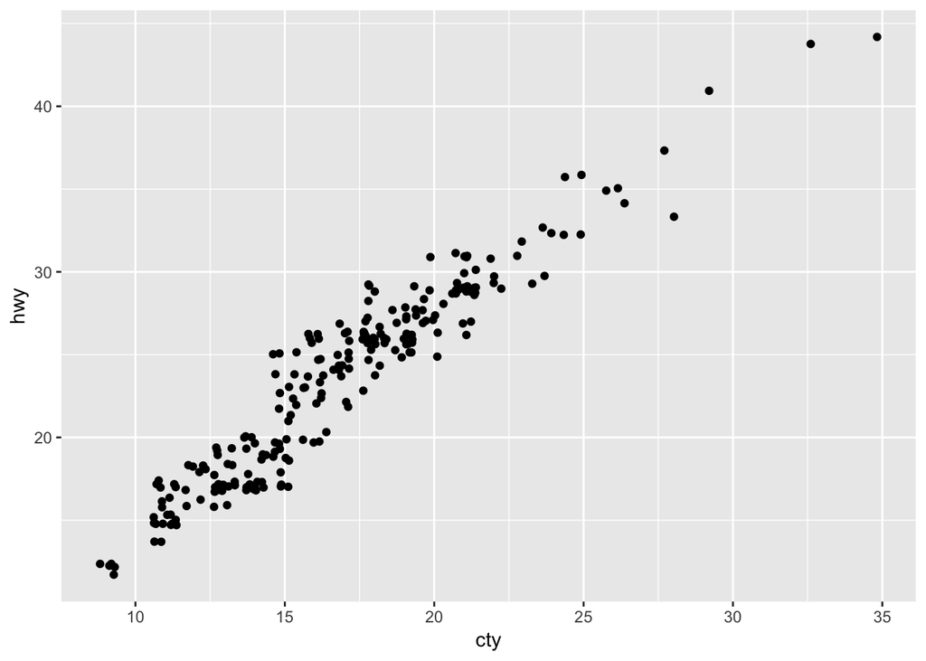

   ```r
   ggplot(data = mpg, mapping = aes(x = cty, y = hwy)) +
       geom_jitter()
   ```

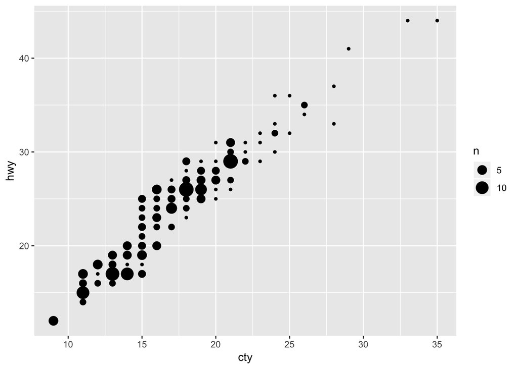

   ```r
   ggplot(data = mpg, mapping = aes(x = cty, y = hwy)) +
       geom_count()
   ```

   - `geom_jitter()` adds random noises to the original data points, which reduces the effect of overplotting.
   - `geom_count()` resizes the point according to the number of observations at each location. Points with more observations will be larger than those with fewer observations.

# Exercise 6

1. Turn a stacked bar chart into a pie chart using `coord_polar()`.

   Answer:

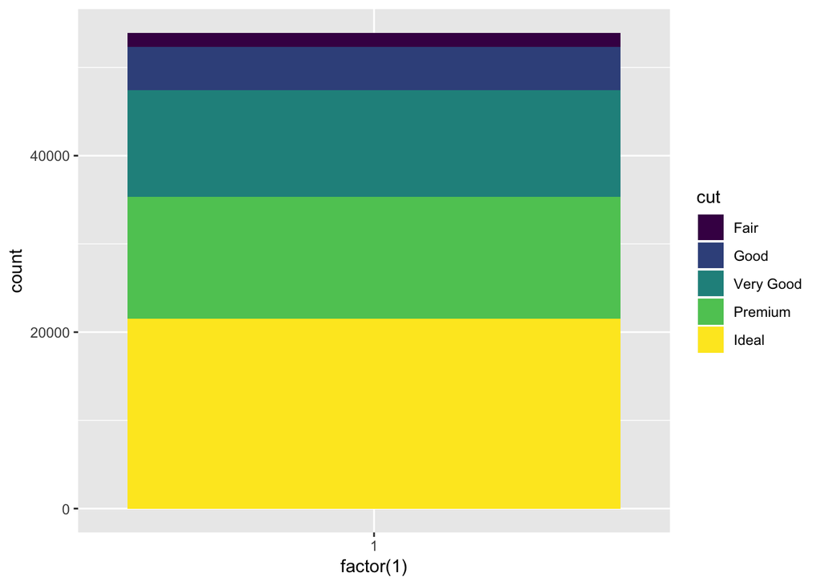

   ```r
   bar <- ggplot(data = diamonds) +
     geom_bar(
       mapping = aes(x = factor(1), fill = cut),
       width = 1
     )

   bar
   ```

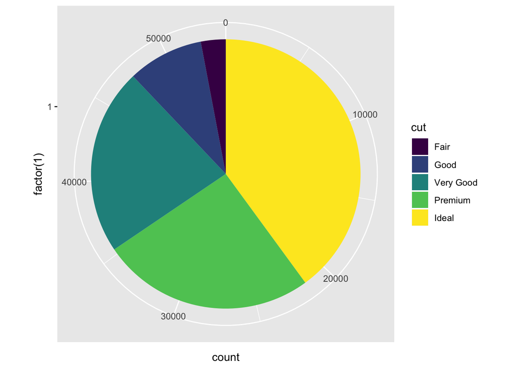

   ```r
   bar + coord_polar(theta = "y")
   ```

2. What does `labs()` do? Read the documentation.

   Answer:

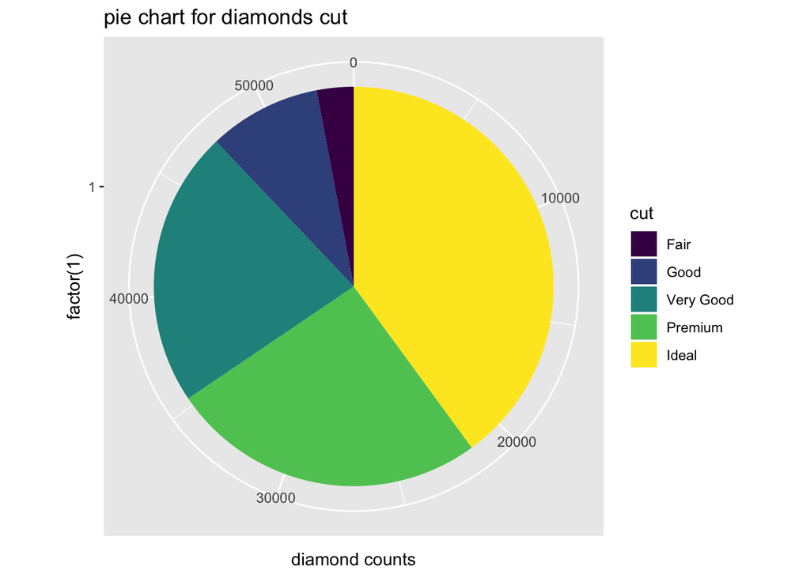

   ```r
   bar <- ggplot(data = diamonds) +
     geom_bar(
       mapping = aes(x = factor(1), fill = cut),
       width = 1
     )

   bar + coord_polar(theta = "y") + labs(x = "factor(1)", y = "diamond counts", title = "pie chart for diamonds cut")
   ```

   The `labs()` can add text for axis, plot title or caption below the plot.
3. What does the plot below tell you about the relationship between city and highway mpg? Why is `coord_fixed()` important? What does `geom_abline()` do?

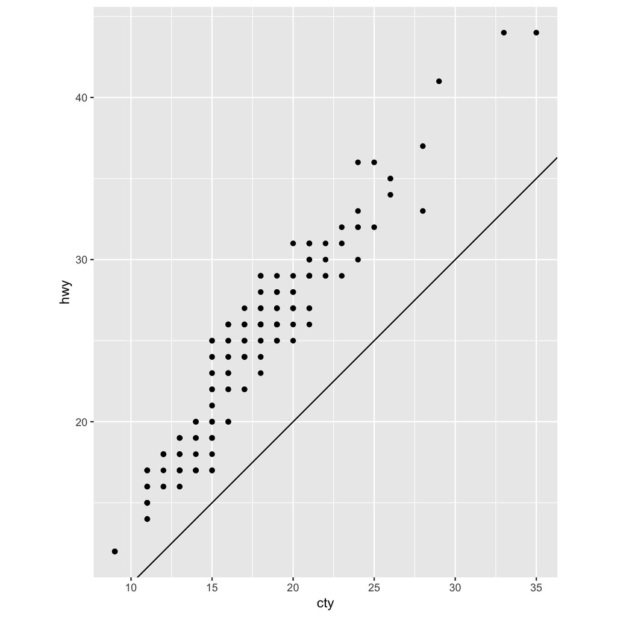

   ```r
   ggplot(data = mpg, mapping = aes(x = cty, y = hwy)) +
     geom_point() +
     geom_abline() +
     coord_fixed()
   ```